# R을 이용한 데이터 전처리 숙제 2

Author

waterfirst

[figure not shown]

아래는 데이터 시각화 문제입니다.

## 1 Photo 공정 데이터

다음은 포토 공정을 통해 PDL 이란 유기막 공정 진행 후 CD를 측정한 값이다.

OLED의 개구부를 형성하는 유기막 재료개발을 하려고 2종의 재료를 코팅 두께, 노광량, 현상 시간을 조절하여 Target CD 40을 만족하는 최적 조건을 찾으려고 한다.

target CD를 만족하면서 공정 산포가 최소가 되는 재료와 공정 조건을 R을 통해 찾으시오

**1. 전처리를 통해 두 재료의 공정조건별 CD 평균, 표준편차를 구하시오** **2. Boxplot을 통해 데이터를 시각화 하시오**

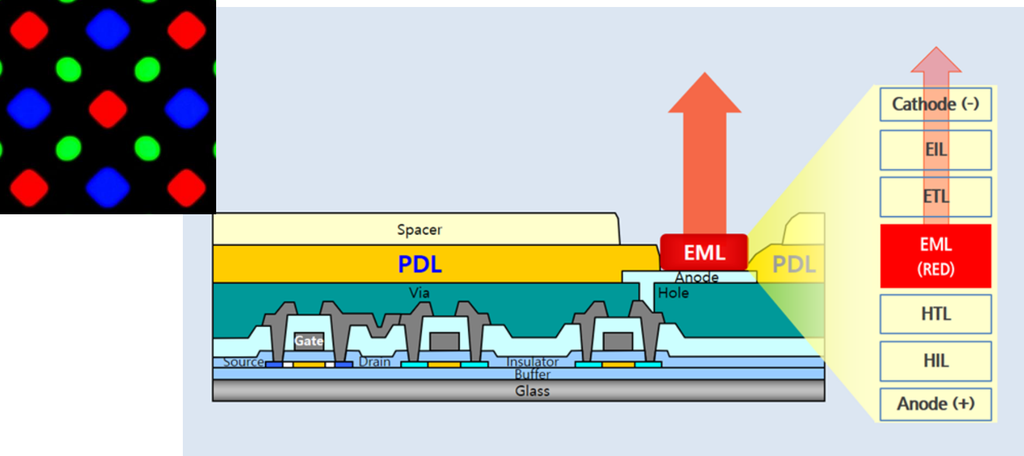

[figure not shown]

데이터셋 위치 : https://raw.githubusercontent.com/waterfirst/Data_visualization/main/data/cd.csv

```r
library(tidyverse)
cd <- read.csv("https://raw.githubusercontent.com/waterfirst/Data_visualization/main/data/cd.csv")
head(cd)
```

```
  glass point material Tpr exp dev    cd
1     1     1        A 2.5  50  50 35.15
2     1     2        A 2.5  50  50 35.40
3     1     3        A 2.5  50  50 35.39
4     1     4        A 2.5  50  50 34.50
5     1     5        A 2.5  50  50 35.17
6     1     6        A 2.5  50  50 34.84
```

데이터 분석 결과 예시

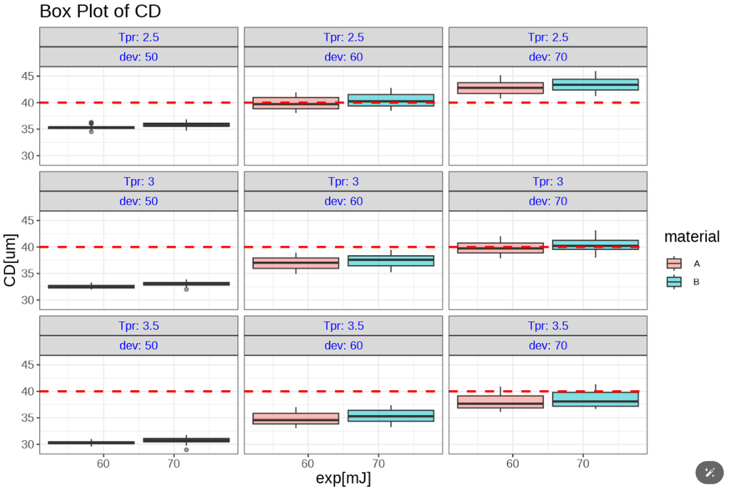

## 2 Dry 공정 데이터

다음은 드라이 에치 공정을 통해 최적의 metal etch 조건을 잡으려고 합니다.

Recipe 5종을 이용하여 metal etch 후 원장의 CD를 측정하였다. 가장 Uniformity가 좋은 recipe를 찾으시오

1. Recipe별 CD 편차
2. Boxplot, violin, histogram, Heat map 등 을 이용하여 원장 CD MAP을 시각화 하시오

데이터셋 위치 : https://raw.githubusercontent.com/waterfirst/Data_visualization/main/data/dry_etch.csv

```r
library(tidyverse)
dry <- read.csv("https://raw.githubusercontent.com/waterfirst/Data_visualization/main/data/dry_etch.csv")
head(dry)
```

```
   recipe gas_cf4 gas_o2 pressure time x1 y1   cd
1 recipe1    2000    500       50   30  1  1 2.82
2 recipe1    2000    500       50   30  1  2 2.82
3 recipe1    2000    500       50   30  1  3 2.87
4 recipe1    2000    500       50   30  1  4 3.11
5 recipe1    2000    500       50   30  1  5 3.53
6 recipe1    2000    500       50   30  1  6 2.83
```

데이터 분석 결과 예시

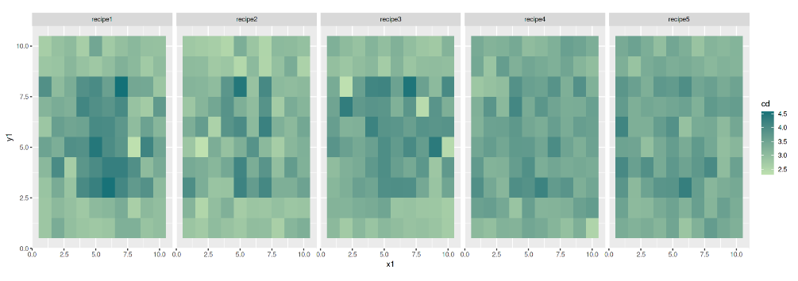